# Income Effects, Substitution, and Elasticity

September 24, 2018

## Feedback

### Good:

- I like that you make sure that the class is still with you before moving on to the next topic.

### Needs improvement:

- If you do a small like end of the week review on Friday for like 5 minutes of key points would be nice.
- The sapling questions where you drag answers into boxes is confusing and doesn’t give good feedback.
- Why have grades never been transferred over to blackboard?

## Substitution effects

- **Substitution Effect** - *The effect (on quantity demanded) of a change in the price of a good as consumers substitute a good that has become relatively cheaper for the good that has become relatively more expensive.*

## Income effects

- **Income Effect** - *The effect (on quantity demanded) of a change in the price of a good due to the new price’s effect on the consumer’s purchasing power.*

## Graphing Income and Substitution Effects

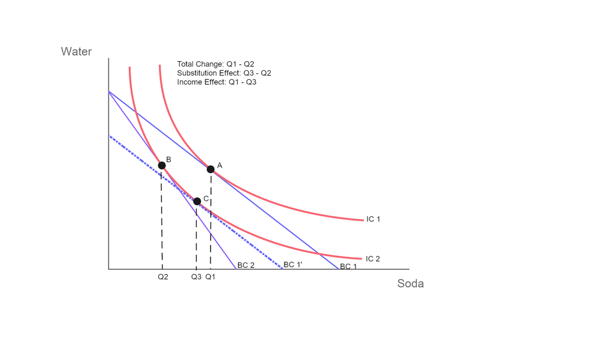

## Giffen Goods

- **Giffen Good** - *A good that is an inferior good and that requires a substantial portion of the consumer’s income. As a result, for a price increasee, demand will actually increase, since the consumer becomes relatively poorer and so spends even more money on the inferior good.*

[interactive chart not shown]

[via GIPHY](https://giphy.com/gifs/collision-muskox-o4K79OHW1ql7W)

EXAMPLE TIME

## Wrapping Up

- Complete the [knowledge check](https://goo.gl/forms/c6yydQptWHoBvIOg2) for today’s participation point.
- Please provide [feedback](https://goo.gl/forms/8SiOwdi19kN8cINJ3) on today’s lecture.